# Problem Set 10

Author

Affiliation

Vesth. Laust.

Department of Economics, Aarhus University - BSS, Fuglesangsalé 4.

**Display Libraries**

```r
library(tidyverse)
library(knitr)
library(wooldridge)
library(dplyr)
library(haven)
library(kableExtra)
library(DT)
library(gtsummary)
library(latex2exp)
library(broom)
library(stargazer)
library(car)
library(Hmisc)
library(ggeffects)
library(lmtest)
library(sandwich)
library(fixest)
```

**Exercises Overview**

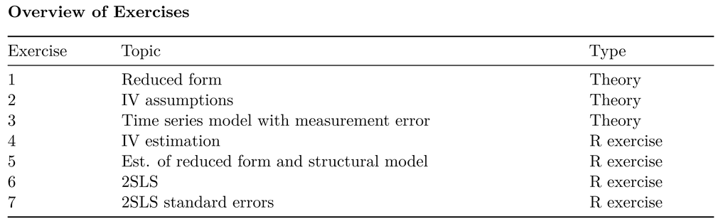

### Exercise 7.

**2SLS standard errors**

*Wooldridge Exercise 15.C9 (p. 528)*

**Display Task**

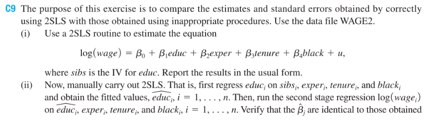

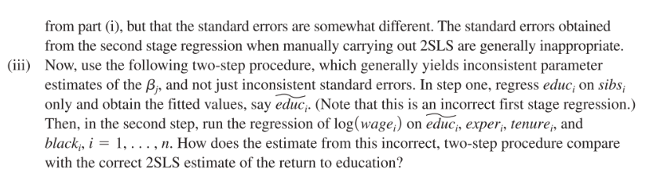

**Display Solution**

*(i)*

We estimate the equation in R.

The equation is given by:

$$\log(\text{wage})=\beta_0+\beta_1\text{educ}+\beta_2\text{exper}+\beta_3\text{tenure}+\beta_4\text{black}+u$$
**`2SLS` (Two-Stage Least Squares)**

*`2SLS` is a method used in econometrics to estimate causal effects when one or more explanatory variables are endogenous.*

$\text{Endogenous} = \text{Correlated with the error term} \Longrightarrow \text{causes bias in OLS.}$ $\text{Exogenous} = \text{Uncorrelated with the error term} \Longrightarrow \text{safe to use in OLS.}$

**Why use `2SLS`?**

When an explanatory variable *(like education)* is influenced by other factors that also affect the outcome *(like wages)*, OLS gives biased results.

For example, ability affects both education and wages, but if ability is unobserved, it ends up in the error term which implies that education becomes endogenous.

`2SLS` solves this by using an *“instrument”*:

- An instrument *(Z)* affects the endogenous variable *(X)* but is not correlated with the error term *(u)*.

Example: distance to college `(nearc4)` affects education *(X)*, but not directly wages *(Y)*.

**How `2SLS` works:**

*Stage 1:*

- Regress the endogenous variable *(X)* on the instrument*(s)* *(Z)* and any exogenous controls.
- Get the predicted values: these are *“clean”* versions of *X*, free from the problematic correlation with *u*.

*Stage 2:*

- Regress the outcome variable *(Y)* on the predicted values from stage 1 *(and any exogenous controls)*.
- This gives a consistent estimate of the causal effect.

**Summary:**

- OLS fails with endogeneity.
- `2SLS` replaces the problematic variable with a version that’s not correlated with the error.
- As long as the instrument is valid *(relevant and exogenous)*, `2SLS` gives consistent estimates.

In R:

**Display Code**

```r
data <- read_dta("C:/Users/laust/Documents/Fag/4. Sem/Econometrics/data/wage2.dta")
```

The following line estimates a `2SLS` (Two-Stage Least Squares) regression using the `fixest` package in R.

```r
model <- feols(lwage ~ exper + tenure + black |0| educ ~ sibs, data=data)
```

We are estimating the model:

$$\log(wage) = \beta_0 + \beta_1 \cdot educ + \beta_2 \cdot exper + \beta_3 \cdot tenure + \beta_4 \cdot black + u$$
Because $educ$ is endogenous, we use $sibs$ as an instrument.

Explanation of the parts:

`lwage ~ exper + tenure + black`:  
These are the exogenous regressors. They are assumed to be uncorrelated with the error term $u$.

`| 0 |`:  
This means no fixed effects are included. Fixed effects could be included here if needed.

`educ ~ sibs`:  
This specifies the instrumental variable. It means $educ$ is endogenous and should be instrumented using $sibs$.

**How 2SLS works:**

*Stage 1:*

Regress $educ$ on $sibs$ and the exogenous variables ($exper$, $tenure$, $black$).  
This gives the predicted values of $educ$ that are uncorrelated with the error term $u$.

*Stage 2:*

Regress $lwage$ on the predicted values of $educ$ (from stage 1), along with $exper$, $tenure$, and $black$.

This procedure removes the endogeneity problem, giving a consistent estimate of the causal effect of education on wages.

**The instrument $sibs$ is valid if:**

1. It is correlated with $educ$ (relevance).
2. It is uncorrelated with $u$ (exogeneity).

If these hold, the 2SLS estimate of $\beta_1$ is consistent.

Model summary below:

```r
tidy_model <- tidy(model)
kbl(tidy_model, format="html", digits=4, booktabs = TRUE) %>% kable_styling(full_width=FALSE)
```

| term | estimate | std.error | statistic | p.value |
| --- | --- | --- | --- | --- |
| (Intercept) | 5.2160 | 0.5435 | 9.5979 | 0.0000 |
| fit_educ | 0.0936 | 0.0337 | 2.7768 | 0.0056 |
| exper | 0.0209 | 0.0084 | 2.4943 | 0.0128 |
| tenure | 0.0115 | 0.0027 | 4.2152 | 0.0000 |
| black | -0.1833 | 0.0501 | -3.6566 | 0.0003 |

We observe that all coefficients in the model are **statistically significant** at conventional levels *(p < 0.05)*, and we interpret them as follows:

- The estimated return to education is **0.0936**, meaning one additional year of education increases log(wage) by approximately **9.36%**, holding other factors constant.  
  This is a **causal effect**, since education was instrumented using `sibs`.
- The coefficient on `exper` is **0.0209**, suggesting that each additional year of work experience increases log(wage) by about **2.09%**.
- The coefficient on `tenure` is **0.0115**, meaning that staying longer at the same job also increases wages, by **1.15% per year**.
- The variable `black` has a negative coefficient of **-0.1833**, indicating that, all else equal, Black individuals earn about **18.33% less** than others, on average.
- The constant term (intercept) is **5.2160**, which represents the expected log(wage) when all regressors are zero — not meaningful by itself but needed for the model.

**Final words:**  
All variables are significant, and the estimated return to education is **positive, large, and statistically significant**, even after correcting for endogeneity using 2SLS.

`sibs` (number of siblings) is a **reasonable instrument** for `educ` (years of education) if it satisfies two key conditions:

1. **Relevance**
   The instrument must be **correlated** with the endogenous variable ($educ$).
   In this case, it is likely that individuals with more siblings receive **less education**, due to limited family resources (like time, money, or attention).
   So, we expect:
   $$Cov(sibs, educ) \neq 0$$
   This is called the **instrument relevance condition**.
2. **Exogeneity**
   The instrument must be **uncorrelated** with the error term in the wage equation.
   This means `sibs` must affect **wages only through its effect on education**, not directly or through unobserved factors (like ability).
   So, we want:
   $$Cov(sibs, u) = 0$$
   This is the **exclusion restriction** or **instrument exogeneity**.

**Why `sibs` makes sense:**

- It’s usually **determined early in life**, before schooling and wages are set.
- It reflects **family background**, which can affect education but not necessarily wages directly.
- It is **plausibly exogenous**: unless parents choose family size based on wage expectations for a specific child (unlikely), `sibs` should not be related to the wage error term.

**Caveat:**  
The validity of `sibs` as an instrument depends on the assumption that it **does not influence wages through any other channel than education**.

If, for example, family size also affects personality, motivation, or network access (which influence wages), then this assumption may be violated.

**Conclusion:**  
`sibs` is a reasonable instrument for `educ` **if** we believe it affects wages **only by influencing how much education someone gets**, and not directly.

*(ii)*

In this task we are asked to **manually perform a 2SLS (Two-Stage Least Squares)** regression, step by step, instead of using a built-in function like `feols()`.

**Step 1: First-stage regression**

Regress the endogenous variable `educ` on the instrument: `sibs` and the exogenous controls: `exper`, `tenure`, `black`.

This yields the **fitted values** (predicted values) of education, denoted:
$$\hat{educ}_i$$

These predicted values are the “clean” version of `educ`, not affected by endogeneity.

**Step 2: Second-stage regression**

We take the predicted values from step 1, and run this regression:

$$\log(wage_i) = \beta_0 + \beta_1 \hat{educ}_i + \beta_2 exper_i + \beta_3 tenure_i + \beta_4 black_i + u_i$$

This yields the estimated coefficients $\hat{\beta}_1, \hat{\beta}_2, \dots$.

What to check:

- The **coefficients** from this manual 2SLS should match the ones from the automatic `feols(... | ... | educ ~ sibs)` regression.
- The **standard errors**, however, will usually be different — and **not valid**, because the second-stage OLS does not account for the fact that $\hat{educ}_i$ is a generated regressor.

Why is this useful?

- It demonstrates how `2SLS` really works behind the scenes.
- It confirms that the logic of instrumental variables leads to the same result.
- It is a reminder that **only specialized functions** like `feols()` give correct **standard errors** for `IV/2SLS`-models.

In R:

**Display Code**

In our calculations we use the packages haven, dplyr and broom.

**First stage:**

```r
# Here we regress educ on `sibs + controls` as follows
stage_1 <- lm(educ ~ sibs + exper + tenure + black, data = data)
```

This runs the **first-stage regression** where education is predicted using the instrument `sibs` and the exogenous control variables `exper`, `tenure`, `black`.

This corresponds to:
$$educ_i = \pi_0 + \pi_1 \cdot sibs_i + \pi_2 \cdot exper_i + \pi_3 \cdot tenure_i + \pi_4 \cdot black_i + v_i$$

```r
# Storing the predicted (fitted) values from the first stage as follows
data <- data %>%
  mutate(educ_hat = fitted(stage_1))
```

This adds a new column `educ_hat` to the data, which contains the **predicted values of `educ`** based on the first-stage regression. These values are free from endogeneity.

**Second stage:**

```r
# Regressing 'lwage' on predicted 'educ' and controls as follows
stage_2 <- lm(lwage ~ educ_hat + exper + tenure + black, data = data)
```

This runs the **second-stage regression**, using the predicted education variable (`educ_hat`) instead of the original (endogenous) `educ`.

This corresponds to:
$$\log(wage_i) = \beta_0 + \beta_1 \cdot \hat{educ}_i + \beta_2 \cdot exper_i + \beta_3 \cdot tenure_i + \beta_4 \cdot black_i + u_i$$

Displaying second stage as follows:

```r
tidy_stage_2 <- tidy(stage_2)
kbl(tidy_stage_2, format="html", digits=4, booktabs=TRUE) %>% kable_styling(full_width = FALSE)
```

Current regression yields the following.

| term | estimate | std.error | statistic | p.value |
| --- | --- | --- | --- | --- |
| (Intercept) | 5.2160 | 0.5688 | 9.1699 | 0.0000 |
| educ_hat | 0.0936 | 0.0353 | 2.6530 | 0.0081 |
| exper | 0.0209 | 0.0088 | 2.3831 | 0.0174 |
| tenure | 0.0115 | 0.0029 | 4.0272 | 0.0001 |
| black | -0.1833 | 0.0525 | -3.4936 | 0.0005 |

The previous regression yielded the following.

| term | estimate | std.error | statistic | p.value |
| --- | --- | --- | --- | --- |
| (Intercept) | 5.2160 | 0.5435 | 9.5979 | 0.0000 |
| fit_educ | 0.0936 | 0.0337 | 2.7768 | 0.0056 |
| exper | 0.0209 | 0.0084 | 2.4943 | 0.0128 |
| tenure | 0.0115 | 0.0027 | 4.2152 | 0.0000 |
| black | -0.1833 | 0.0501 | -3.6566 | 0.0003 |

**Comparison of Manual 2SLS vs Proper 2SLS**

| Term | Coef (manual) | SE (manual) | Coef (feols) | SE (feols) | Difference |
| --- | --- | --- | --- | --- | --- |
| Intercept | 5.2160 | 0.5688 | 5.2160 | 0.5435 | 0.0000 |
| Education | 0.0936 | 0.0353 | 0.0936 | 0.0337 | 0.0000 |
| Experience | 0.0209 | 0.0088 | 0.0209 | 0.0084 | 0.0000 |
| Tenure | 0.0115 | 0.0029 | 0.0115 | 0.0027 | 0.0000 |
| Black | -0.1833 | 0.0525 | -0.1833 | 0.0501 | 0.0000 |

**Interpretation:**

*All coefficients are identical across both models*, which confirms that the *manual `2SLS`* is implemented correctly. However, the *standard errors differ slightly*:

**Conclusion:**

- Coefficient estimates are *the same* — this confirms the math of `2SLS`.
- Standard errors from `feols()` are *correct and preferred*.
- It should be that one should *never report standard errors* from manual 2SLS unless they are adjusted using special packages or variance formulas.

It is much more wise to be using `feols()` (or similar tools like `ivreg()`) for valid inference.

*(iii)*

In this task we must *intentionally perform an incorrect two-stage regression* in order to *see what goes wrong* when `2SLS` is not done properly.

We are tasked with:

**Step 1 (incorrect first stage):**  
Regressing `educ` *only* on `sibs`, not including other exogenous controls (`exper`, `tenure`, `black`).

This gives:
$$\hat{educ}_i = \pi_0 + \pi_1 \cdot sibs_i$$

**Step 2:**
Taking the predicted values from the incorrect first stage, and plug them into the second-stage regression:
$$\log(wage_i) = \beta_0 + \beta_1 \cdot \hat{educ}_i + \beta_2 \cdot exper_i + \beta_3 \cdot tenure_i + \beta_4 \cdot black_i + u_i$$

**Why is this wrong?:**

In proper `2SLS`, the *first stage must include all exogenous regressors* from the second stage — this maintains orthogonality conditions and ensures consistency.

Omitting them breaks the logic of the instrument and means:

- The predicted values of `educ` are *not properly isolated from the error term* in the second stage.
- The result is an *inconsistent estimate* of the effect of education ($\beta_1$).
- We are not just getting incorrect *standard errors* — the actual *coefficient is biased*.

**What might be the purpose of the task:**

To *compare the incorrect estimate of the return to education* with the *correct 2SLS estimate*, and see how much the bias affects the result.

What we want to look for in the output:

- The coefficient on `educ` (i.e. return to education) in the incorrect model.
- Compare it with the correct `2SLS` estimate.
- Likely, the incorrect estimate will be **different and biased**, confirming that 2SLS only works when done properly.

In R:

**Display Code**

```r
#1. An incorrect first stage - here we only regress educ on sibs
incorrect_stage_1 <- lm(educ ~ sibs, data = data)

# saving the predicted values of educ in the dataset
data$educ_tilde <- fitted(incorrect_stage_1)

#2. Regressing lwage on the incorrect predicted values and other controls
incorrect_stage_2 <- lm(lwage ~ educ_tilde + exper + tenure + black, data = data)
```

```r
#Loading the results into a table...
tidy_incorrect_stage_2 <- tidy(incorrect_stage_2)
kbl(tidy_incorrect_stage_2, format="html", digits=4, booktabs=TRUE) %>% kable_styling(full_width=FALSE)
```

The incorrect model:

| term | estimate | std.error | statistic | p.value |
| --- | --- | --- | --- | --- |
| (Intercept) | 5.7710 | 0.3604 | 16.0139 | 0.0000 |
| educ_tilde | 0.0700 | 0.0264 | 2.6530 | 0.0081 |
| exper | -0.0004 | 0.0031 | -0.1262 | 0.8996 |
| tenure | 0.0140 | 0.0027 | 5.1932 | 0.0000 |
| black | -0.2416 | 0.0415 | -5.8185 | 0.0000 |

Comparing with the model from *(i)*:

| term | estimate | std.error | statistic | p.value |
| --- | --- | --- | --- | --- |
| (Intercept) | 5.2160 | 0.5435 | 9.5979 | 0.0000 |
| fit_educ | 0.0936 | 0.0337 | 2.7768 | 0.0056 |
| exper | 0.0209 | 0.0084 | 2.4943 | 0.0128 |
| tenure | 0.0115 | 0.0027 | 4.2152 | 0.0000 |
| black | -0.1833 | 0.0501 | -3.6566 | 0.0003 |

We observe that not accounting for all explanetory variables that is not correlated with the error term introduces bias into the analysis making the results more dis satisfactory and incorrect.

Model comparinson and interpretation follows.

**The Incorrect Model (from part iii)**

| Variable | Coefficient | p-value | Interpretation |
| --- | --- | --- | --- |
| (Intercept) | 5.7710 | 0.0000 | Baseline log(wage) when all variables are 0. |
| educ_tilde | 0.0700 | 0.0081 | A 1-year increase in education (from incorrect first stage) increases log(wage) by ~7%. Statistically significant. |
| exper | -0.0004 | 0.8996 | No effect. Not significant at all. Likely distorted by incorrect first stage. |
| tenure | 0.0140 | 0.0000 | Each year of tenure increases log(wage) by ~1.4%. Highly significant. |
| black | -0.2416 | 0.0000 | Being Black is associated with ~24.2% lower log(wage). Highly significant. |

**The Correct Model (from part i)**

| Variable | Coefficient | p-value | Interpretation |
| --- | --- | --- | --- |
| (Intercept) | 5.2160 | 0.0000 | Baseline log(wage) when all variables are 0. |
| fit_educ | 0.0936 | 0.0056 | A 1-year increase in education (correct 2SLS) increases log(wage) by ~9.4%. Statistically significant. |
| exper | 0.0209 | 0.0128 | Each year of experience increases log(wage) by ~2.1%. Significant. |
| tenure | 0.0115 | 0.0000 | Each year of tenure increases log(wage) by ~1.15%. Highly significant. |
| black | -0.1833 | 0.0003 | Being Black is associated with ~18.3% lower log(wage). Highly significant. |

Summary:

- The incorrect model *underestimates* the return to education.
- It produces a *nonsensical coefficient for experience* (wrong sign, not significant).
- This shows that *excluding controls from the first stage leads to biased estimates*, not just incorrect standard errors.